# EDUCATION IN INDIA - DATA ANALYSIS

```python
import numpy as np
import pandas as pd
import os
```

```python
##Data Source: https://www.kaggle.com/datasets/rajanand/education-in-india?rvi=1
districtwise_raw_df = pd.read_csv('Data/2015_16_Districtwise.csv')
```

```python
districtwise_raw_df
```

|  | AC_YEAR | STATCD | DISTCD | STATNAME | DISTNAME | DISTRICTS | BLOCKS | VILLAGES | CLUSTERS | TOTPOPULAT | ... | UUNI_ALL | UUNI_SC | UUNI_ST | TOTCLS1G | TOTCLS2G | TOTCLS3G | TOTCLS4G | TOTCLS5G | TOTCLS6G | TOTCLS7G |
| --- | --- | --- | --- | --- | --- | --- | --- | --- | --- | --- | --- | --- | --- | --- | --- | --- | --- | --- | --- | --- | --- |
| 0 | 2015-16 | 1 | 101 | JAMMU & KASHMIR | KUPWARA | 1 | 13 | 391 | 104 | 875564.0 | ... | 21322 | 26 | 2594 | 3489 | 5315 | 27 | 62 | 23 | 852 | 239 |
| 1 | 2015-16 | 1 | 102 | JAMMU & KASHMIR | BARAMULA | 1 | 18 | 678 | 144 | 1015503.0 | ... | 17307 | 0 | 1571 | 4127 | 5800 | 210 | 53 | 30 | 1665 | 360 |
| 2 | 2015-16 | 1 | 103 | JAMMU & KASHMIR | SRINAGAR | 1 | 8 | 94 | 65 | 1269751.0 | ... | 5444 | 31 | 408 | 817 | 3284 | 886 | 11 | 0 | 2873 | 40 |
| 3 | 2015-16 | 1 | 104 | JAMMU & KASHMIR | BADGAM | 1 | 13 | 523 | 104 | 735753.0 | ... | 12469 | 18 | 857 | 2290 | 3837 | 119 | 45 | 8 | 1035 | 325 |
| 4 | 2015-16 | 1 | 105 | JAMMU & KASHMIR | PULWAMA | 1 | 8 | 359 | 64 | 570060.0 | ... | 7408 | 17 | 855 | 1688 | 2584 | 151 | 67 | 5 | 1101 | 209 |
| ... | ... | ... | ... | ... | ... | ... | ... | ... | ... | ... | ... | ... | ... | ... | ... | ... | ... | ... | ... | ... | ... |
| 675 | 2015-16 | 36 | 3606 | TELANGANA | RANGA REDDY | 1 | 37 | 876 | 137 | 5296396.0 | ... | 93203 | 25534 | 9457 | 7224 | 8298 | 529 | 0 | 121 | 15458 | 3337 |
| 676 | 2015-16 | 36 | 3607 | TELANGANA | MAHBUBNAGAR | 1 | 64 | 1458 | 230 | 4042191.0 | ... | 134277 | 31001 | 14590 | 8936 | 7007 | 179 | 0 | 44 | 3730 | 3327 |
| 677 | 2015-16 | 36 | 3608 | TELANGANA | NALGONDA | 1 | 59 | 1117 | 216 | 3483648.0 | ... | 96804 | 26577 | 14015 | 7592 | 4534 | 103 | 0 | 208 | 4026 | 3049 |
| 678 | 2015-16 | 36 | 3609 | TELANGANA | WARANGAL | 1 | 51 | 993 | 211 | 3522644.0 | ... | 92224 | 23172 | 23525 | 6674 | 4677 | 153 | 0 | 207 | 7035 | 3060 |
| 679 | 2015-16 | 36 | 3610 | TELANGANA | KHAMMAM | 1 | 41 | 783 | 185 | 2798214.0 | ... | 70234 | 15593 | 25217 | 6047 | 4015 | 104 | 0 | 32 | 3103 | 2228 |

680 rows × 819 columns

This data has around 5,50,000 enteries giving infomation about population, students, teachers ect in each state and its corosponding district.

```python
districtwise_raw_df.columns
```

```
Index(['AC_YEAR', 'STATCD', 'DISTCD', 'STATNAME', 'DISTNAME', 'DISTRICTS',
       'BLOCKS', 'VILLAGES', 'CLUSTERS', 'TOTPOPULAT',
       ...
       'UUNI_ALL', 'UUNI_SC', 'UUNI_ST', 'TOTCLS1G', 'TOTCLS2G', 'TOTCLS3G',
       'TOTCLS4G', 'TOTCLS5G', 'TOTCLS6G', 'TOTCLS7G'],
      dtype='object', length=819)
```

It appears that shortcodes for the entries have been used as column names. We can refer to the "Districtwise_Metadata" file to see the full name of each column. The schema file contains only two columns: Field Name and Description. We can load it as Pandas Series with Field Name as the index and the Description as the value.

```python
districtwise_metadata = 'Data/2015_16_Districtwise_Metadata.csv'
metadata_raw = pd.read_csv(districtwise_metadata, index_col='Field Name').Description
```

```python
metadata_raw
```

```
Field Name
STATCD                          Data_Reported_from: State code
DISTCD                       Data_Reported_from: District Code
STATNAME                        Data_Reported_from: State name
DISTNAME                     Data_Reported_from: District name
DISTRICTS                  Data_Reported_from: No. of district
                                   ...
TOTCLS3G     Total_Classrooms_Primary_with_upper_Primary_Se...
TOTCLS4G     Total_Classrooms_Upper_Primary_Only: Upper_Pri...
TOTCLS5G     Total_Classrooms_Upper_Primary_with_Sec./H.Sec...
TOTCLS6G     Total_Classrooms_Primary_with_upper_Primary_Se...
TOTCLS7G     Total_Classrooms_Upper_Primary_with_Sec.: Uppe...
Name: Description, Length: 821, dtype: object
```

We can now use metadata_raw to retrieve the full name of columns in districtwise_raw_df.

```python
metadata_raw['STATNAME']
```

```
Field Name
STATNAME             Data_Reported_from: State name
STATNAME    Data_Reported_From_Data_Reported_from:
Name: Description, dtype: object
```

Looks like any thing starting with capital 'T' is total of its corosponding coloumns. We will consider only total for our analysis. For Example Total students, total schools etc.

```python
project='education_analysis_india'
```

# Data Preparation & Cleaning

While this data contain a wealth of information, we'll limit our analysis to the following areas:

Blockwise analysis of population, schools, teachers, students both government and private at different levels like primary, upperprimary, high schools and senior seconday. We will also drill down till classroom level in each school to see which all classrooms are equiped with technology.

```python
start_column_name = 'STATNAME'
end_column_name = 'TCHTOTP'

# Select columns from start_column_name to end_column_name
selected_columns_df = districtwise_raw_df.loc[:, start_column_name:end_column_name]
```

```python
districtwise_df = selected_columns_df
```

```python
districtwise_df.shape
```

```
(680, 172)
```

```python
districtwise_df.info()
```

```
<class 'pandas.core.frame.DataFrame'>
RangeIndex: 680 entries, 0 to 679
Columns: 172 entries, STATNAME to TCHTOTP
dtypes: float64(13), int64(157), object(2)
memory usage: 913.9+ KB
```

```python
districtwise_df.describe()
```

|  | DISTRICTS | BLOCKS | VILLAGES | CLUSTERS | TOTPOPULAT | P_URB_POP | POPULATION_0_6 | GROWTHRATE | SEXRATIO | P_SC_POP | ... | TCHTOTG | TCH1P | TCH2P | TCH3P | TCH4P | TCH5P | TCH6P | TCH7P | TCH9P | TCHTOTP |
| --- | --- | --- | --- | --- | --- | --- | --- | --- | --- | --- | --- | --- | --- | --- | --- | --- | --- | --- | --- | --- | --- |
| count | 680.0 | 680.000000 | 680.000000 | 680.000000 | 6.340000e+02 | 631.000000 | 6.330000e+02 | 634.000000 | 634.000000 | 633.000000 | ... | 680.000000 | 680.000000 | 680.000000 | 680.000000 | 680.000000 | 680.000000 | 680.000000 | 680.000000 | 680.0 | 680.000000 |
| mean | 1.0 | 10.760294 | 874.614706 | 121.226471 | 1.899024e+06 | 24.819255 | 2.494264e+05 | 17.627886 | 942.678233 | 14.875340 | ... | 6873.933824 | 860.977941 | 1211.001471 | 955.570588 | 190.995588 | 446.745588 | 682.832353 | 316.367647 | 0.0 | 4664.491176 |
| std | 0.0 | 9.585360 | 622.711657 | 94.040172 | 1.547475e+06 | 19.093744 | 1.985112e+05 | 11.346020 | 62.415774 | 9.149862 | ... | 4993.816014 | 1233.910758 | 1506.147630 | 1705.787153 | 457.756646 | 1024.800324 | 1138.138758 | 962.734110 | 0.0 | 4920.148120 |
| min | 1.0 | 1.000000 | 6.000000 | 1.000000 | 7.948000e+03 | -25.350000 | 1.103980e+03 | -58.390000 | 533.000000 | 0.000000 | ... | 136.000000 | 0.000000 | 0.000000 | 0.000000 | 0.000000 | 0.000000 | 0.000000 | 0.000000 | 0.0 | 0.000000 |
| 25% | 1.0 | 5.000000 | 390.750000 | 56.750000 | 8.226940e+05 | 11.375000 | 1.087804e+05 | 12.052500 | 904.250000 | 7.500000 | ... | 3713.750000 | 127.750000 | 294.500000 | 55.000000 | 0.000000 | 0.000000 | 88.000000 | 0.000000 | 0.0 | 1307.000000 |
| 50% | 1.0 | 8.000000 | 785.500000 | 101.000000 | 1.564392e+06 | 19.500000 | 2.040779e+05 | 17.055000 | 946.000000 | 15.760000 | ... | 5843.500000 | 353.500000 | 721.500000 | 270.000000 | 8.000000 | 27.500000 | 323.500000 | 28.000000 | 0.0 | 3240.000000 |
| 75% | 1.0 | 13.000000 | 1204.250000 | 162.500000 | 2.587520e+06 | 32.420000 | 3.378675e+05 | 22.740000 | 981.000000 | 20.800000 | ... | 8628.250000 | 1016.750000 | 1526.500000 | 1152.250000 | 95.250000 | 284.750000 | 846.250000 | 196.250000 | 0.0 | 6248.250000 |
| max | 1.0 | 66.000000 | 3963.000000 | 592.000000 | 1.105413e+07 | 100.000000 | 1.256855e+06 | 111.010000 | 1176.000000 | 50.170000 | ... | 40378.000000 | 10800.000000 | 13919.000000 | 18401.000000 | 3173.000000 | 9680.000000 | 12451.000000 | 15401.000000 | 0.0 | 47275.000000 |

8 rows × 170 columns

Now we have perfect data for our analysis and visualisation.

```python
districtwise_df.sample(10)
```

|  | STATNAME | DISTNAME | DISTRICTS | BLOCKS | VILLAGES | CLUSTERS | TOTPOPULAT | P_URB_POP | POPULATION_0_6 | GROWTHRATE | ... | TCHTOTG | TCH1P | TCH2P | TCH3P | TCH4P | TCH5P | TCH6P | TCH7P | TCH9P | TCHTOTP |
| --- | --- | --- | --- | --- | --- | --- | --- | --- | --- | --- | --- | --- | --- | --- | --- | --- | --- | --- | --- | --- | --- |
| 300 | TRIPURA | DHALAI | 1 | 9 | 176 | 56 | 377988.0 | 10.71 | 54430.27 | 22.78 | ... | 4655 | 205 | 90 | 67 | 0 | 30 | 36 | 0 | 0 | 428 |
| 500 | GUJARAT | MAHESANA | 1 | 10 | 730 | 146 | 2027727.0 | 14.96 | 227713.74 | 9.91 | ... | 7886 | 378 | 1501 | 542 | 266 | 95 | 216 | 9 | 0 | 3007 |
| 643 | TAMIL NADU | THE NILGIRIS | 1 | 4 | 53 | 45 | 735071.0 | 59.32 | 61672.46 | -3.55 | ... | 3383 | 872 | 142 | 535 | 4 | 547 | 783 | 155 | 0 | 3038 |
| 32 | HIMACHAL PRADESH | SHIMLA | 1 | 20 | 1639 | 321 | 813384.0 | 24.77 | 80769.03 | 12.58 | ... | 9854 | 500 | 990 | 1338 | 0 | 11 | 1348 | 0 | 0 | 4187 |
| 271 | NAGALAND | TUENSANG | 1 | 5 | 126 | 14 | 196801.0 | 18.72 | 34833.78 | 5.81 | ... | 1939 | 65 | 196 | 70 | 0 | 0 | 320 | 0 | 0 | 651 |
| 458 | MADHYA PRADESH | SATNA | 1 | 8 | 1840 | 99 | 2228619.0 | 21.30 | 320921.14 | 19.17 | ... | 9529 | 622 | 4734 | 1973 | 9 | 79 | 1120 | 0 | 0 | 8537 |
| 560 | MAHARASHTRA | LATUR | 1 | 12 | 1193 | 137 | 2455543.0 | 25.47 | 307679.54 | 18.04 | ... | 6072 | 1444 | 3524 | 115 | 14 | 3631 | 433 | 2623 | 0 | 11784 |
| 162 | UTTAR PRADESH | KANNAUJ | 1 | 9 | 819 | 98 | 1658005.0 | 16.92 | 251519.36 | 19.37 | ... | 4970 | 1663 | 276 | 76 | 1131 | 1315 | 25 | 355 | 0 | 4841 |
| 569 | ANDHRA PRADESH | SRIKAKULAM | 1 | 38 | 1521 | 397 | 2699471.0 | 16.16 | 265358.00 | 6.38 | ... | 13049 | 807 | 1286 | 4 | 0 | 0 | 415 | 992 | 0 | 3504 |
| 222 | BIHAR | GOPALGANJ | 1 | 14 | 1358 | 120 | 2558037.0 | 6.32 | 436912.72 | 18.83 | ... | 11841 | 127 | 1649 | 59 | 15 | 32 | 52 | 0 | 0 | 1934 |

10 rows × 172 columns

```python
districtwise_df.to_csv('districtwise_data.csv', index=False)
```

# Exploratory Analysis and Visualization

Let's begin by importing matplotlib.pyplot and seaborn.

```python
import seaborn as sns
import matplotlib
import matplotlib.pyplot as plt
%matplotlib inline
sns.set_style('darkgrid')
import ipywidgets as widgets
from ipywidgets import interact
```

## Q1.Which state has highest literacy?

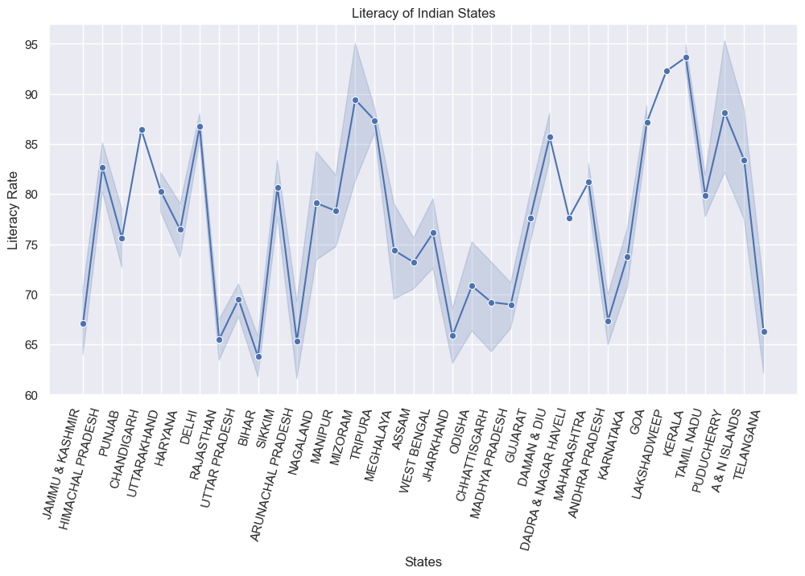

```python
# Create a line plot using Seaborn
plt.figure(figsize=(12, 6))
sns.lineplot(x='STATNAME', y='OVERALL_LI', data=districtwise_df, marker='o')

# Rotate x-axis labels for better readability
plt.xticks(rotation=75, ha='right')

# Set labels and title
plt.title('Literacy of Indian States')
plt.xlabel('States')
plt.ylabel('Literacy Rate')

# Show the plot
plt.show()
```

Kerala is the state in India with highest literacy.

To find out, choose a state from the dropdown menu and explore the distribution of schools across districts within that state.

```python
# Function to update the bar graph based on the selected STATNAME
@interact(STATNAME=districtwise_df['STATNAME'].unique())
def plot_bar_graph(STATNAME):
    # Filter the DataFrame based on the selected STATNAME
    filtered_df = districtwise_df[districtwise_raw_df['STATNAME'] == STATNAME]

    # Create a bar plot using Seaborn
    plt.figure(figsize=(12, 6))
    sns.barplot(x='DISTNAME', y='SCHTOT', data=filtered_df)

    # Set labels and title
    plt.xlabel('Districts')
    plt.ylabel('Total Schools')
    plt.title(f'Number of Schools - {STATNAME}')

    # Rotate x-axis labels for better readability
    plt.xticks(rotation=45, ha='right')

    # Show the plot
    plt.show()
```

```
interactive(children=(Dropdown(description='STATNAME', options=('JAMMU & KASHMIR', 'HIMACHAL PRADESH', 'PUNJAB…
```

## Q3.What is the breakdown between government and private schools in the total number of schools?

To find out, choose a state and the type of school from the dropdown menu and explore the distribution of schools across districts within that state.

```python
# Function to update the bar graph based on the selected STATNAME and Type of School
@interact(STATNAME=districtwise_df['STATNAME'].unique(), School_Type=['All', 'Government', 'Private'])
def plot_bar_graph(STATNAME, School_Type):
    # Filter the DataFrame based on the selected STATNAME
    filtered_df = districtwise_df[districtwise_df['STATNAME'] == STATNAME]

    # Determine the column based on the selected School_Type
    if School_Type == 'All':
        column = 'SCHTOT'
    elif School_Type == 'Government':
        column = 'SCHTOTG'
    elif School_Type == 'Private':
        column = 'SCHTOTP'
    else:
        raise ValueError('Invalid School_Type selected')

    # Create a bar plot using Seaborn
    plt.figure(figsize=(12, 6))
    sns.barplot(x='DISTNAME', y=column, data=filtered_df)

    # Set labels and title
    plt.xlabel('Districts')
    plt.ylabel(column)
    plt.title(f'Number of Schools - {STATNAME} ({School_Type} Schools)')

    # Rotate x-axis labels for better readability
    plt.xticks(rotation=45, ha='right')

    # Show the plot
    plt.show()
```

```
interactive(children=(Dropdown(description='STATNAME', options=('JAMMU & KASHMIR', 'HIMACHAL PRADESH', 'PUNJAB…
```

## Q5.What is the distribution of teachers in government and private schools across states?

Select a state and the type of school from the dropdown menu to observe the district-wise distribution of teachers within each state.

```python
# Function to update the bar graph based on the selected STATNAME and Type of School
@interact(STATNAME=districtwise_df['STATNAME'].unique(), School_Type=['Government', 'Private'])
def plot_bar_graph(STATNAME, School_Type):
    # Filter the DataFrame based on the selected STATNAME
    filtered_df = districtwise_df[districtwise_df['STATNAME'] == STATNAME]

    # Determine the column based on the selected School_Type
    if School_Type == 'Government':
        column = 'TCHTOTG'
    elif School_Type == 'Private':
        column = 'TCHTOTP'
    else:
        raise ValueError('Invalid School_Type selected')

    # Create a bar plot using Seaborn
    plt.figure(figsize=(12, 6))
    sns.barplot(x='DISTNAME', y=column, data=filtered_df)

    # Set labels and title
    plt.xlabel('Districts')
    plt.ylabel(column)
    plt.title(f'Number of Teachers - {STATNAME} ({School_Type} Schools)')

    # Rotate x-axis labels for better readability
    plt.xticks(rotation=45, ha='right')

    # Show the plot
    plt.show()
```

```
interactive(children=(Dropdown(description='STATNAME', options=('JAMMU & KASHMIR', 'HIMACHAL PRADESH', 'PUNJAB…
```

## Q6.What is the distribution of students in government and private schools across states?

Select a state and the type of school from the dropdown menu to observe the district-wise distribution of students within each state.

```python
# Function to update the bar graph based on the selected STATNAME and Type of School
@interact(STATNAME=districtwise_df['STATNAME'].unique(), School_Type=['All', 'Government', 'Private'])
def plot_bar_graph(STATNAME, School_Type):
    # Filter the DataFrame based on the selected STATNAME
    filtered_df = districtwise_df[districtwise_df['STATNAME'] == STATNAME]

    # Determine the column based on the selected School_Type
    if School_Type == 'All':
        column = 'ENRTOT'
    elif School_Type == 'Government':
        column = 'ENRTOTG'
    elif School_Type == 'Private':
        column = 'ENRTOTP'
    else:
        raise ValueError('Invalid School_Type selected')

    # Create a bar plot using Seaborn
    plt.figure(figsize=(12, 6))
    sns.barplot(x='DISTNAME', y=column, data=filtered_df)

    # Set labels and title
    plt.xlabel('Districts')
    plt.ylabel(column)
    plt.title(f'Number of Students - {STATNAME} ({School_Type} Schools)')

    # Rotate x-axis labels for better readability
    plt.xticks(rotation=45, ha='right')

    # Show the plot
    plt.show()
```

```
interactive(children=(Dropdown(description='STATNAME', options=('JAMMU & KASHMIR', 'HIMACHAL PRADESH', 'PUNJAB…
```

## Q7.How many schools in each state are equipped with computers?

Select a state from the dropdown menu to observe the number of classrooms with computers in each state.

```python
# Function to update the bar graph based on the selected STATNAME
@interact(STATNAME=districtwise_raw_df['STATNAME'].unique())
def plot_bar_graph(STATNAME):
    # Filter the DataFrame based on the selected STATNAME
    filtered_df = districtwise_raw_df[districtwise_raw_df['STATNAME'] == STATNAME]

    # Create a bar plot using Seaborn
    plt.figure(figsize=(12, 6))
    sns.barplot(x='DISTNAME', y='SCOMPTOT', data=filtered_df)

    # Set labels and title
    plt.xlabel('DISTNAME')
    plt.ylabel('Number of Classrooms with Computers')
    plt.title(f'Number of Classrooms with Computers in Districts - {STATNAME}')

    # Rotate x-axis labels for better readability
    plt.xticks(rotation=45, ha='right')

    # Show the plot
    plt.show()
```

```
interactive(children=(Dropdown(description='STATNAME', options=('JAMMU & KASHMIR', 'HIMACHAL PRADESH', 'PUNJAB…
```

# Conclusion

Based on the analysis of the education data for the Indian market, here are some key insights and conclusions that could be relevant for an eLearning company targeting this market:

### 1. Regional Disparities in Literacy:

- The literacy rates vary significantly across different states, indicating regional disparities in educational attainment.
- Targeting states with lower literacy rates may present opportunities for interventions and educational programs.

### 2. Technology Infrastructure in Schools:

- The analysis of classrooms with computers, provides insights into the technological infrastructure in schools across different districts.
- Identifying districts with a higher number of classrooms with computers could be crucial for targeting areas with better technology adoption.
- Analyzing data on schools with computers can guide the development of eLearning content that aligns with the technological infrastructure in different regions.

### 3. Government vs. Private Schools:

- The availability of data on government and private schools allows for a comparison of educational facilities and resources between these two types of institutions.
- Understanding the differences can help tailor eLearning solutions to meet the specific needs of each type of school.
- The distinct decision-making autonomy of private schools, in contrast to government institutions, facilitates a more accessible entry into the market as needed.

### 4. State-specific Strategies:

- The interactive visualizations with dropdowns for state selection enable a granular analysis at the state and district levels.
- Tailoring marketing and content strategies based on state-specific characteristics and needs can enhance the effectiveness of eLearning initiatives.

### 5. Opportunities for Intervention:

- Identification of states or districts with lower literacy rates and fewer classrooms with computers presents opportunities for targeted interventions and collaborations with local educational authorities.

### 6. Marketing and Outreach:

- Marketing efforts can be tailored to highlight the relevance of eLearning solutions in addressing specific educational challenges observed in different states and districts.

### Summarising:

Using data to understand how education works in India is really helpful for eLearning companies to make smart decisions. By tailoring their strategies to fit the specific needs of different regions and schools, they can be more successful in reaching and helping students all over India.